# MUSA 500, Assignment #1

Minwook Kang, Nissim Lebovits, Ann Zhang

2022-10-03

## 0.1 Introduction

State the problem and the setting of the analysis (i.e., Philadelphia).

Present either a brief review of the literature (use Google Scholar) or simply speculate as to why the predictors we’re using might be related with the response variable.

## 0.2 Methods

### 0.2.1 Data Cleaning

The original Philadelphia block group datasets has 1816 observations. We clean the data by removing the following block groups:

1. Block groups where population < 40
2. Block groups where there are no housing units
3. Block groups where the median house value is lower than $10,000
4. One North Philadelphia block group which had a very high median house value (over $800,000) and a very low median household income (less than $8,000)

The final dataset contains 1720 block groups.

### 0.2.2 Exploratory Data Analysis

State that you will examine the summary statistics and distributions of variables.

Also state that as part of your exploratory data analysis, you will examine the correlations between the predictors.

Explain what a correlation is, and provide the formula for the sample correlation coefficient r. Also mention the possible range of r values, and what correlation of 0 means.

### 0.2.3 Multiple Regression Analysis

Multiple Linear Regression is used to examine the relationship between a variable of interest (dependent variable) and one or more explanatory variables. Goal of this method is to fit a linear relationship between a quantitative dependent variable $Y$ and a set of predictors $X_1,X_2,...,X_i$. This method allows us to calculate the amount by which dependent variable changes when a predictor variable changes by one unit. Similar to correlation, if an explanatory variable is a significant predictor of the dependent variable, it doesn’t imply that the explanatory variable is a cause of the dependent variable. Regression model is widely used in biological, behavioral and social sciences to explain possible relationships between variables.

One of the important assumptions is that **Independent and dependent variables is always linear**. That is, if the value of the independent variable changes, the dependent variable must also change continuously. To check this assumption, most frequently draw Scatterplots between $y$ and each of the predictors $x$. If the relationship is not linear, variable transformation or polynomial regression could be one of other options.

Second assumption is that **each observation and residual has to be independent**. It’s called Homoscedasticity, the variance of the residuals $ε$ is constant regardless of the values of each $x$. That is, the residual by predicted plot and the residual by $X$ plot should show no systematic patterns that for different values of $X$. We can use scatterplots of standardized residuals against each predictor. Presence of heteroscedasticity often means that there is systematic under/over-prediction happening in the model. The inclusion of additional predictors, running a spatial regression may help reduce or eliminate heteroscedasticity.

**Normality of residuals** are important for point estimation, confidence intervals, and hypothesis tests only for small samples due to the Central Limit Theorem. But if we have a large sample size(>30), isn’t as important as some of other assumptions. By looking as the histogram of residuals, we can check they are whether normal or not. We are generally more likely to see normal residuals if the dependent variable is normal and the predictor variables are normal. Violations of normality of residuals might arise either because the dependent or independent variables are themselves non-normal, or the linearity assumptions violated. In such cases, a nonlinear transformation of variables might solve both problems. In some cases, the problem with the residual distribution is mainly due to one or two very large errors, so called Outliers. If they are merely errors or if they can be explained as unique events not likely to be repeated, then you may able to remove them.

Predictor variables shouldn’t be strongly correlated with each other, that is **non-Multicollinearity**. If correlation between any pair of predictors r>0.8 or r<-0.8, we might have Multicollinearity. Better Ways of Testing for Multicollinearity is to claculate VIF(Variance Inflation Factor). The VIF for each predictor $i$ is defined as follows :
$$VIF_k = \frac{1}{1-R_i^2}$$
. a VIF of 1 means that there is no correlation among the $i^th$ predictor and the remaining predictor variables. The general rule of thumb is that VIF exceeding 4 warrant further investigation, while VIF exceeding 10 are signs of serious multicollinearity requiring correction.

multiple OLS regression requires us to estimate values for a critical set of parameters: a regression constant and one regression coefficient for each independent variable in our model. The regression constant tells us the predicted value of the dependent variable (DV, hereafter) when all of the independent variables (IVs, hereafter) equal 0. The unstandardized regression coefficient for each IV tells us how much the predicted value of the DV would change with a one-unit increase in the IV, when all other IVs are at 0. OLS estimates these parameters by finding the values for the constant and coefficients that minimize the sum of the squared errors of prediction, i.e., the differences between a case’s actual score on the DV and the score we predict for them using actual scores on the IVs. A matrix of $β$ Coefficient, $\textrm{B}$ is given by :
$$\textrm{B}\;=\;\textrm{(X´X)}^{-1}\textrm{(X´Y)}$$
. $\textrm{Y}$ is an $N×1$ column matrix of cases’ scores on the DV, $\textrm{X}$ is an $N×(k+1)$ matrix of cases’ scores on the IVs (where the first column is a placeholder column of ones for the constant and the remaining columns correspond to each IV), $\textrm{B}$ is a $(k+1)×1$ column matrix containing the regression constant and coefficients.

$SST = \sum(y_i-y_i)^2$ $R^2 = 1- \frac{SSE}{SST}$

$$R^2_{adj} = \frac{(n-1)R^2-k}{n-(k+1)}$$

Before doing a hypothesis test for each individual predictor, we do a so-called model utility test, referred to as the F-ratio.

### 0.2.4 Additional Analyses

Talk about stepwise regression – discuss what it does and its limitations

Talk about k-fold cross-validation (mentioning that k = 5) – discuss what it is used for, describe how it is operationalized and mention that the RMSE is used to compare models (explain what the RMSE is and how it is calculated, presenting and describing any relevant formulas).

### 0.2.5 Tools

The analyses and visualizations for this report have all been done in R.

## 0.3 Results

### 0.3.1 Exploratory Results

#### 0.3.1.1 Setup

#### 0.3.1.2 Import data

In order to complete this entire project in R (rather than using ArcGIS, too), we have chosen to use the shapefile of data, rather than the .csv. Below, we import the shapefile and use a custom function to apply log transformations to the relevant columns. The function checks whether there are zero values in each column and then applies the appropriate log transformation accordingly.

```r
#Nissim
#reg_data = read_sf('C:/Users/Nissim/Desktop/Fall 2022/Spat Stats/ass_1_data_shp/RegressionData.shp')

#Min
reg_data = read_sf('C:/Users/vestalk/Desktop/00_Upenn/20.Fall/03.MUSA 5000 Spatial Statistics and Data Analysis/Assignment/HW1/RegressionData.shp')


#define a function to find zero values in columns
col_zeros = function(a, b) {
                  pct_col_zeros = count(subset(st_drop_geometry(a), b != 0)) |>
                                      pull(n) / nrow(st_drop_geometry(a))
                  return(pct_col_zeros)
                  }


#apply function with case_when statement
#case_when is a vectorized function, while ifelse is not.
#running this with ifelse will result in all row values in the mutated column being the same.
reg_data = reg_data |>
            mutate(
                ln_med_h_val = case_when(col_zeros(reg_data, reg_data$MEDHVAL) == 1 ~ log(reg_data$MEDHVAL),
                                     TRUE ~ log(1 + reg_data$MEDHVAL)),
                   ln_pct_bach_more = case_when(col_zeros(reg_data, reg_data$PCTBACHMOR) == 1 ~ log(reg_data$PCTBACHMOR),
                                     TRUE ~ log(1 + reg_data$PCTBACHMOR)),
                   ln_n_bel_pov_100 = case_when(col_zeros(reg_data, reg_data$NBelPov100) == 1 ~ log(reg_data$NBelPov100),
                                     TRUE ~ log(1 + reg_data$NBelPov100)),
                   ln_pct_vacant = case_when(col_zeros(reg_data, reg_data$PCTVACANT) == 1 ~ log(reg_data$PCTVACANT),
                                     TRUE ~ log(1 + reg_data$PCTVACANT)),
                   ln_pct_singles = case_when(col_zeros(reg_data, reg_data$PCTSINGLES) == 1 ~ log(reg_data$PCTSINGLES),
                                     TRUE ~ log(1 + reg_data$PCTSINGLES)),
                  )
```

#### 0.3.1.3 Data Table

Present and briefly talk about the table with summary statistics which includes the dependent variable and the predictors (i.e., mean, standard deviation).

```r
med_house_val = c("Median House Value", round(mean(reg_data$MEDHVAL),2), round(sd(reg_data$MEDHVAL),2))

hhs_in_pov = c("# Households Living in Poverty", round(mean(reg_data$NBelPov100),2), round(sd(reg_data$NBelPov100),2))

pct_w_bach_or_higher = c("% of Individuals with Bachelor's Degrees or Higher", round(mean(reg_data$PCTBACHMOR),2), round(sd(reg_data$PCTBACHMOR),2))

pct_vac_houses = c("% of Vacant Houses", round(mean(reg_data$PCTVACANT),2), round(sd(reg_data$PCTVACANT),2))

pct_sing_house_units = c("% of Single House Units", round(mean(reg_data$PCTSINGLES),2), round(sd(reg_data$PCTSINGLES),2))

table = as.data.frame(t(data.frame(
              med_house_val,
              hhs_in_pov,
              pct_w_bach_or_higher,
              pct_vac_houses,
              pct_sing_house_units
              )))

colnames(table) = c("Variable", "Mean", "SD")


table_out = table |>
        gt() |>
        tab_header(
          title = md("**Summary Statistics**")
        ) |>
        tab_row_group(
          label = md('**Predictors**'),
          rows = 2:5
        ) |>
        tab_row_group(
          label = md('**Dependent Variable**'),
          rows = 1
        )

#print output
table_out
```

**Summary Statistics**

| Variable | Mean | SD |
| --- | --- | --- |
| **Dependent Variable** |  |  |
| Median House Value | 66287.73 | 60006.08 |
| **Predictors** |  |  |
| # Households Living in Poverty | 189.77 | 164.32 |
| % of Individuals with Bachelor's Degrees or Higher | 16.08 | 17.77 |
| % of Vacant Houses | 11.29 | 9.63 |
| % of Single House Units | 9.23 | 13.25 |

#### 0.3.1.4 Histograms

Also state whether the variables are normal before and after the logarithmic transformation

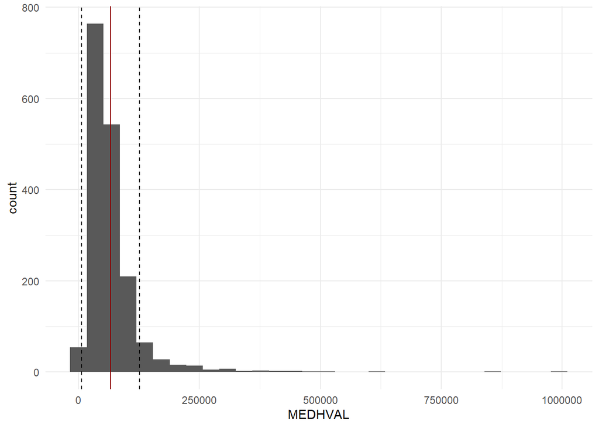

```r
 house_val = ggplot(reg_data) +
                geom_histogram(aes(MEDHVAL)) +
                geom_vline(xintercept = mean(reg_data$MEDHVAL), color = 'darkred') +
    geom_vline(xintercept = (mean(reg_data$MEDHVAL) + sd(reg_data$MEDHVAL)), linetype = 'dashed')+
    geom_vline(xintercept = (mean(reg_data$MEDHVAL) - sd(reg_data$MEDHVAL)), linetype = 'dashed') +
    theme_minimal()

  pct_bach = ggplot(reg_data) +
    geom_histogram(aes(PCTBACHMOR)) +
    geom_vline(xintercept = mean(reg_data$PCTBACHMOR), color = 'darkred') +
    geom_vline(xintercept = (mean(reg_data$PCTBACHMOR) + sd(reg_data$PCTBACHMOR)), linetype = 'dashed')+
    geom_vline(xintercept = (mean(reg_data$PCTBACHMOR) - sd(reg_data$PCTBACHMOR)), linetype = 'dashed') +
    theme_minimal()

  nbelpov = ggplot(reg_data) +
    geom_histogram(aes(NBelPov100)) +
    geom_vline(xintercept = mean(reg_data$NBelPov100), color = 'darkred') +
    geom_vline(xintercept = (mean(reg_data$NBelPov100) + sd(reg_data$NBelPov100)), linetype = 'dashed')+
    geom_vline(xintercept = (mean(reg_data$NBelPov100) - sd(reg_data$NBelPov100)), linetype = 'dashed') +
    theme_minimal()

  pct_vac = ggplot(reg_data) +
    geom_histogram(aes(PCTVACANT)) +
    geom_vline(xintercept = mean(reg_data$PCTVACANT), color = 'darkred') +
    geom_vline(xintercept = (mean(reg_data$PCTVACANT) + sd(reg_data$PCTVACANT)), linetype = 'dashed')+
    geom_vline(xintercept = (mean(reg_data$PCTVACANT) - sd(reg_data$PCTVACANT)), linetype = 'dashed') +
    theme_minimal()

  pct_sing = ggplot(reg_data) +
    geom_histogram(aes(PCTSINGLES)) +
    geom_vline(xintercept = mean(reg_data$PCTSINGLES), color = 'darkred') +
    geom_vline(xintercept = (mean(reg_data$PCTSINGLES) + sd(reg_data$PCTSINGLES)), linetype = 'dashed')+
    geom_vline(xintercept = (mean(reg_data$PCTSINGLES) - sd(reg_data$PCTSINGLES)), linetype = 'dashed') +
    theme_minimal()

  house_val
```

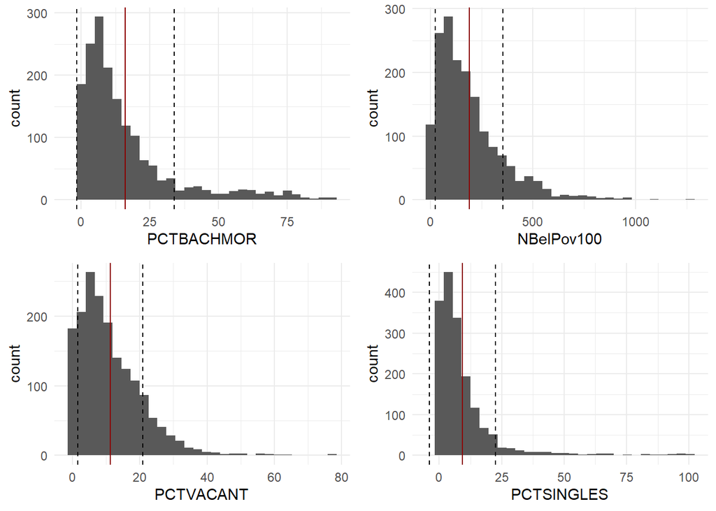

```r
  ggarrange(pct_bach, nbelpov, pct_vac, pct_sing)
```

#### 0.3.1.5 Log Transform Histograms

Present the histograms of the transformed variables and clearly state whether you’re using the log-transformed or original variable in your regression.

State that the other regression assumptions will be examined in a separate section below (Regression Assumption Checks).

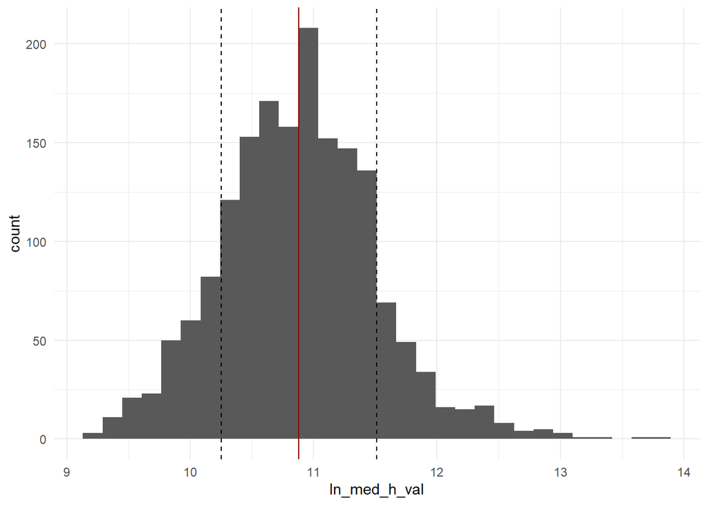

```r
 ln_house_val = ggplot(reg_data) +
                geom_histogram(aes(ln_med_h_val)) +
                geom_vline(xintercept = mean(reg_data$ln_med_h_val), color = 'darkred') +
    geom_vline(xintercept = (mean(reg_data$ln_med_h_val) + sd(reg_data$ln_med_h_val)), linetype = 'dashed')+
    geom_vline(xintercept = (mean(reg_data$ln_med_h_val) - sd(reg_data$ln_med_h_val)), linetype = 'dashed') +
    theme_minimal()

  ln_pct_bach = ggplot(reg_data) +
    geom_histogram(aes(ln_pct_bach_more)) +
    geom_vline(xintercept = mean(reg_data$ln_pct_bach_more), color = 'darkred') +
    geom_vline(xintercept = (mean(reg_data$ln_pct_bach_more) + sd(reg_data$ln_pct_bach_more)), linetype = 'dashed')+
    geom_vline(xintercept = (mean(reg_data$ln_pct_bach_more) - sd(reg_data$ln_pct_bach_more)), linetype = 'dashed') +
    theme_minimal()

  ln_nbelpov = ggplot(reg_data) +
    geom_histogram(aes(ln_n_bel_pov_100)) +
    geom_vline(xintercept = mean(reg_data$ln_n_bel_pov_100), color = 'darkred') +
    geom_vline(xintercept = (mean(reg_data$ln_n_bel_pov_100) + sd(reg_data$ln_n_bel_pov_100)), linetype = 'dashed')+
    geom_vline(xintercept = (mean(reg_data$ln_n_bel_pov_100) - sd(reg_data$ln_n_bel_pov_100)), linetype = 'dashed') +
    theme_minimal()

  ln_pct_vac = ggplot(reg_data) +
    geom_histogram(aes(ln_pct_vacant)) +
    geom_vline(xintercept = mean(reg_data$ln_pct_vacant), color = 'darkred') +
    geom_vline(xintercept = (mean(reg_data$ln_pct_vacant) + sd(reg_data$ln_pct_vacant)), linetype = 'dashed')+
    geom_vline(xintercept = (mean(reg_data$ln_pct_vacant) - sd(reg_data$ln_pct_vacant)), linetype = 'dashed') +
    theme_minimal()

  ln_pct_sing = ggplot(reg_data) +
    geom_histogram(aes(ln_pct_singles)) +
    geom_vline(xintercept = mean(reg_data$ln_pct_singles), color = 'darkred') +
    geom_vline(xintercept = (mean(reg_data$ln_pct_singles) + sd(reg_data$ln_pct_singles)), linetype = 'dashed')+
    geom_vline(xintercept = (mean(reg_data$ln_pct_singles) - sd(reg_data$ln_pct_singles)), linetype = 'dashed') +
    theme_minimal()

  ln_house_val
```

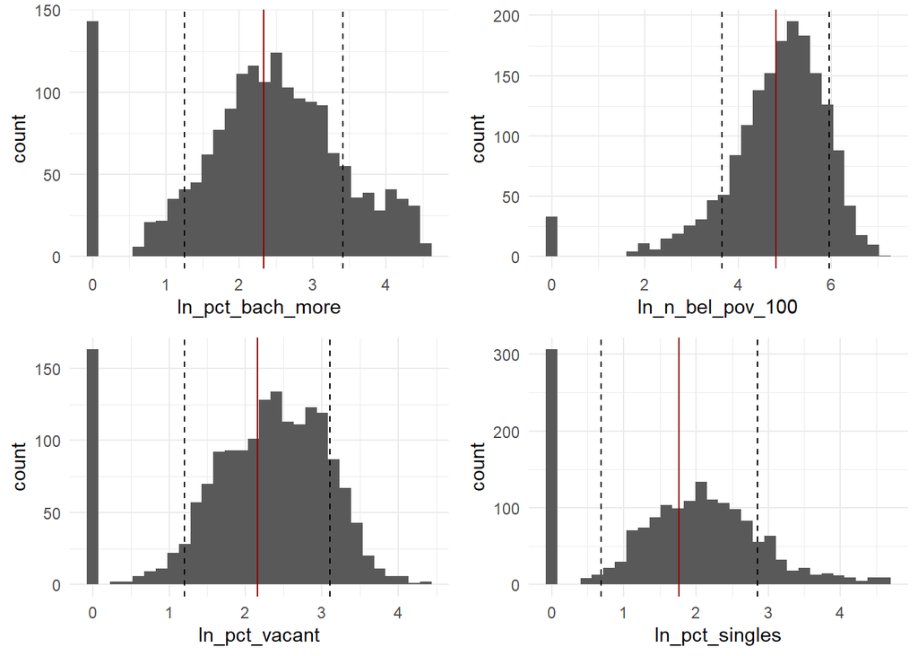

```r
  ggarrange(ln_pct_bach, ln_nbelpov, ln_pct_vac, ln_pct_sing)
```

#### 0.3.1.6 Choropleth Maps

Present the choropleth maps of the dependent variable and the predictors which you created.

Refer to the maps in the text, and talk about the following:

Which maps look similar? Which maps look different? That is, which predictors do you expect to be strongly associated with the dependent variable based on the visualization? Also, given your examination of the maps, are there any predictors that you think will be strongly inter-correlated? That is, do you expect severe multicollinearity to be an issue here? Discuss this in a paragraph.

```r
#lifted from lovelace: https://geocompr.robinlovelace.net/adv-map.html#faceted-maps
tmap_mode("plot")
```

```
## tmap mode set to plotting
```

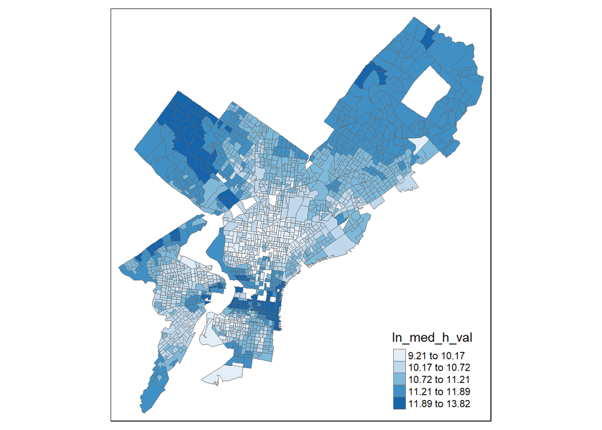

```r
tm_shape(reg_data) +
  tm_polygons(col = "ln_med_h_val", border.col = NA, lwd = 0, palette = "Blues", style = "jenks") +
  tm_layout(legend.position = c("right", "bottom"))
```

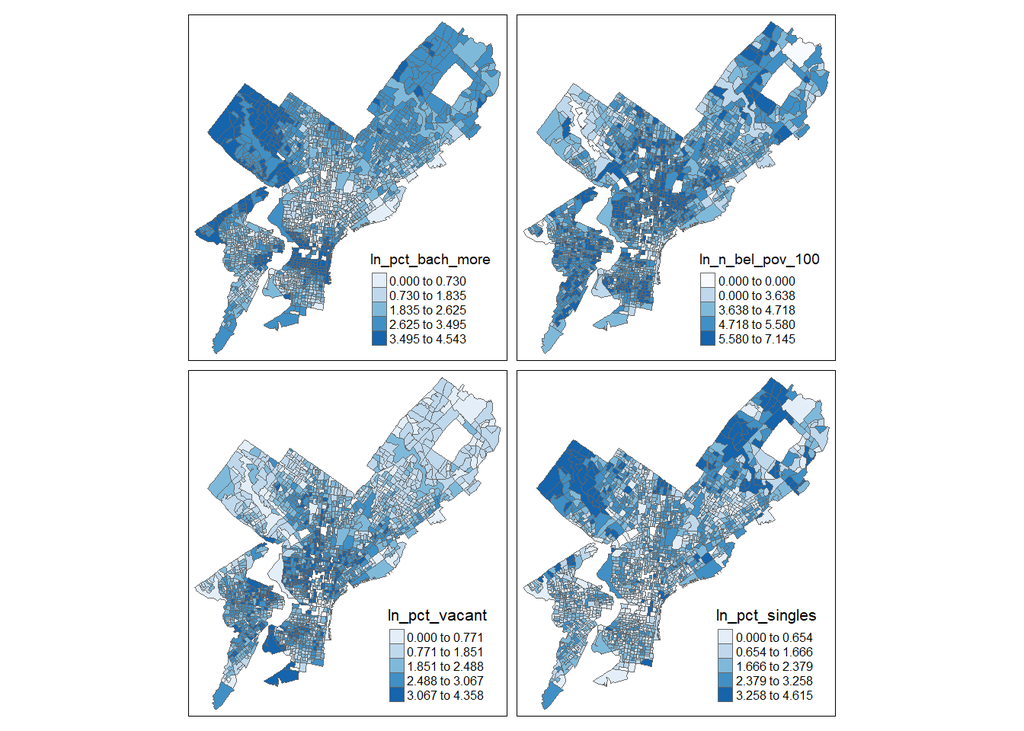

```r
facets = c("ln_pct_bach_more",
           "ln_n_bel_pov_100",
           "ln_pct_vacant",
           "ln_pct_singles")

tm_shape(reg_data) +
  tm_polygons(facets, border.col = NA, lwd = 0, palette = "Blues", style = "jenks") +
  tm_layout(legend.position = c("right", "bottom")) +
  tm_facets(nrow = 2, sync = TRUE)
```

#### 0.3.1.7 Correlation Matrix

Present the correlation matrix of the predictors which you obtained from R.

Talk about whether the correlation matrix shows that there is severe multicollinearity.

Does the correlation matrix support your conclusions based on your visual comparison of predictor maps?

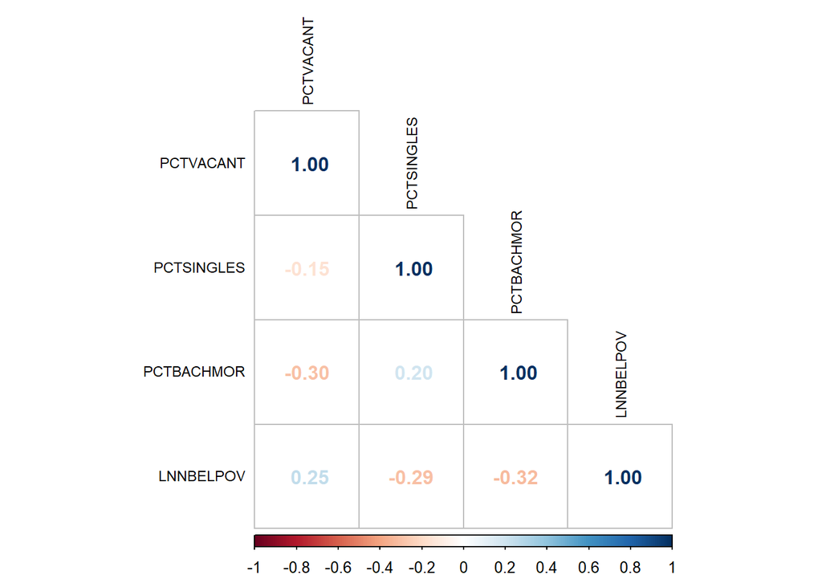

```r
#https://cran.r-project.org/web/packages/corrplot/vignettes/corrplot-intro.html
corr_reg_data = reg_data |>
                  st_drop_geometry() |>
                  dplyr::select(
                                PCTVACANT,
                                PCTSINGLES,
                                PCTBACHMOR,
                                LNNBELPOV)

corrplot(cor(corr_reg_data), method = "number", type = "lower", tl.col = "black", tl.cex = 0.75, number.cex = 1)
```

### 0.3.2 Regression Results

Present the regression output from R. Be sure that your output presents the parameter estimates (and associated standard errors, t-statistics and p-values), as well as the R2, the adjusted R2, and the relevant F-ratio and associated p-value.

Referencing the regression output in (i) above, interpret the results as in the example included above this report outline. NOTE: YOUR DEPENDENT VARIABLE (AND SOME PREDICTORS) WOULD BE LOG-TRANSFORMED, UNLIKE IN THE EXAMPLE HERE. LOOK AT THE SLIDES FOR EXAMPLES OF INTERPRETING REGRESSION OUTPUT WITH LOG-TRANSFORMED VARIABLES.

#### 0.3.2.1 Regression

```r
lm = lm(MEDHVAL ~ PCTVACANT + PCTSINGLES + PCTBACHMOR + ln_n_bel_pov_100, data = reg_data)

summary(lm)
```

```
##
## Call:
## lm(formula = MEDHVAL ~ PCTVACANT + PCTSINGLES + PCTBACHMOR +
##     ln_n_bel_pov_100, data = reg_data)
##
## Residuals:
##     Min      1Q  Median      3Q     Max
## -142167  -13065   -1156   10103  845813
##
## Coefficients:
##                  Estimate Std. Error t value Pr(>|t|)
## (Intercept)      60167.52    5095.12  11.809  < 2e-16 ***
## PCTVACANT         -578.91     107.07  -5.407 7.32e-08 ***
## PCTSINGLES         754.91      76.99   9.805  < 2e-16 ***
## PCTBACHMOR        2051.89      59.48  34.499  < 2e-16 ***
## ln_n_bel_pov_100 -5681.22     925.99  -6.135 1.05e-09 ***
## ---
## Signif. codes:  0 '***' 0.001 '**' 0.01 '*' 0.05 '.' 0.1 ' ' 1
##
## Residual standard error: 40130 on 1715 degrees of freedom
## Multiple R-squared:  0.5538, Adjusted R-squared:  0.5528
## F-statistic: 532.2 on 4 and 1715 DF,  p-value: < 2.2e-16
```

```r
anova(lm)
```

```
## Analysis of Variance Table
##
## Response: MEDHVAL
##                    Df     Sum Sq    Mean Sq  F value    Pr(>F)
## PCTVACANT           1 6.6026e+11 6.6026e+11  410.032 < 2.2e-16 ***
## PCTSINGLES          1 5.0734e+11 5.0734e+11  315.064 < 2.2e-16 ***
## PCTBACHMOR          1 2.1998e+12 2.1998e+12 1366.112 < 2.2e-16 ***
## ln_n_bel_pov_100    1 6.0614e+10 6.0614e+10   37.642 1.053e-09 ***
## Residuals        1715 2.7616e+12 1.6103e+09
## ---
## Signif. codes:  0 '***' 0.001 '**' 0.01 '*' 0.05 '.' 0.1 ' ' 1
```

```r
pred_vals = fitted(lm)

resids = residuals

stand_resids = rstandard(lm)

lm_df = data.frame(reg_data$MEDHVAL, pred_vals, stand_resids) |>
          rename(MEDHVAL = reg_data.MEDHVAL)
```

### 0.3.3 Regression Assumption Checks

First state that in this section, you will be talking about testing model assumptions and aptness. State that you have already looked at the variable distributions earlier.

#### 0.3.3.1 Scatterplots of Predictors

Present scatter plots of the dependent variable and each of the predictors. State whether each of the relationships seems to be linear, as assumed by the regression model. [Hint: they will not look linear.]

Question here: are we meant to be using the original predictors or the log-transformed columns? (See section 1b)

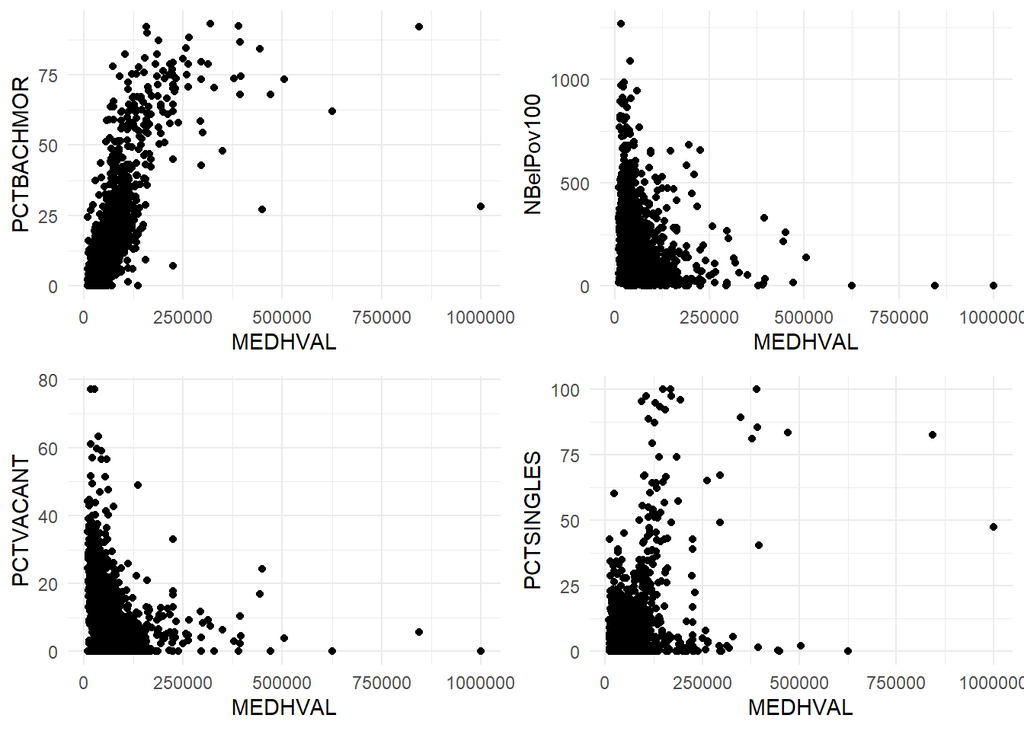

```r
  pct_bach_plot = ggplot(reg_data) +
                    geom_point(aes(x = MEDHVAL,
                                   y = PCTBACHMOR)) +
                    theme_minimal()

  nbelpov_plot = ggplot(reg_data) +
                    geom_point(aes(x = MEDHVAL,
                                   y = NBelPov100)) +
                    theme_minimal()

  pct_vac_plot = ggplot(reg_data) +
                    geom_point(aes(x = MEDHVAL,
                                   y = PCTVACANT)) +
                    theme_minimal()

  pct_sing_plot = ggplot(reg_data) +
                    geom_point(aes(x = MEDHVAL,
                                   y = PCTSINGLES)) +
                    theme_minimal()

  ggarrange(pct_bach_plot, nbelpov_plot, pct_vac_plot, pct_sing_plot)
```

#### 0.3.3.2 Histogram of Standardized Residuals

Present the histogram of the standardized residuals. State whether the residuals look normal.

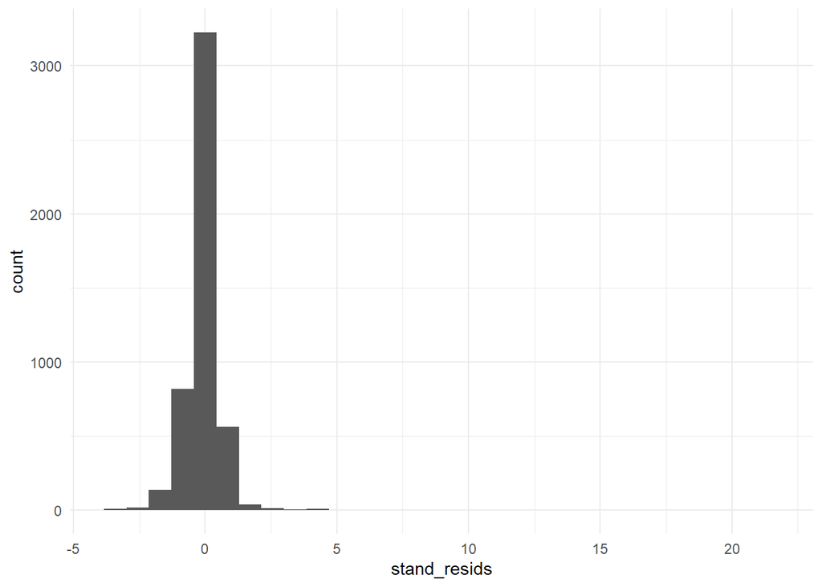

```r
#join lm_df back to reg_data to map stand_resids
#I'm not sure there's an easy way to make sure the rows match, but it should be okay
reg_data = left_join(reg_data, lm_df, by = "MEDHVAL")

ggplot(reg_data) +
  geom_histogram(aes(x = stand_resids)) +
  theme_minimal()
```

#### 0.3.3.3 Standardized Residual by Predicted Value Scatter Plot

Present the ‘Standardized Residual by Predicted Value’ scatter plot. What conclusions can you draw from that? Does there seem to be heteroscedasticity? Do there seem to be outliers? Anything else? Discuss.

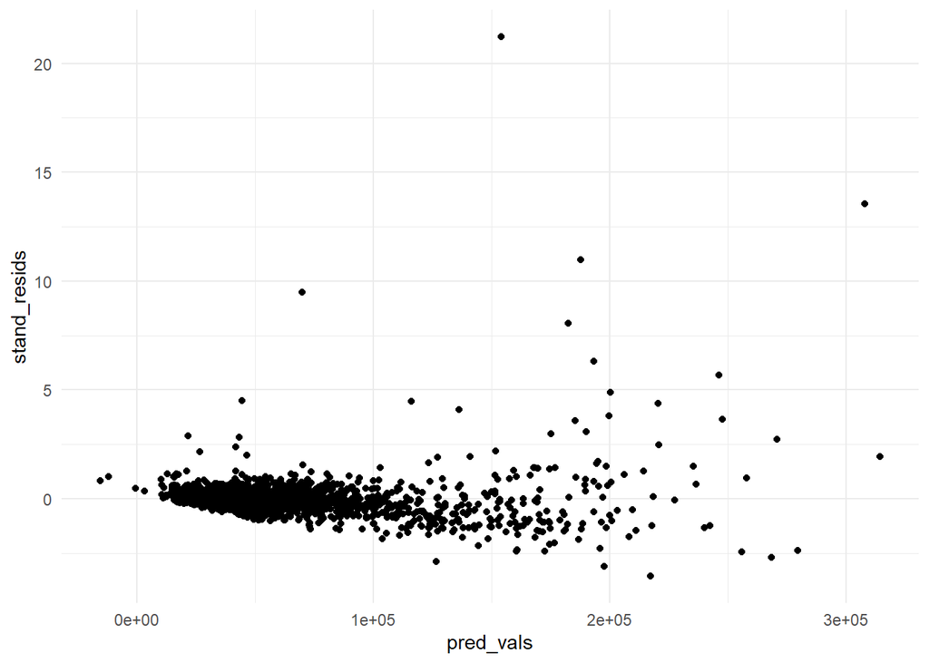

```r
ggplot(lm_df) +
  geom_point(aes(x = pred_vals, y = stand_resids)) +
  theme_minimal()
```

Mention what standardized residuals are.

Referencing the maps of the dependent variable and the predictors that you presented earlier, state whether there seems to be spatial autocorrelation in your variables. That is, does it seem that the observations (i.e., block groups) are independent of each other? Briefly discuss.

#### 0.3.3.4 Histogram & Choropleth of SRRs

Now, present the choropleth map of the standardized regression residuals. Do there seem to be any noticeable spatial patterns in them? That is, do they seem to be spatially autocorrelated?

You will examine the spatial autocorrelation of the variables and residuals and run spatial regressions in the next assignment.

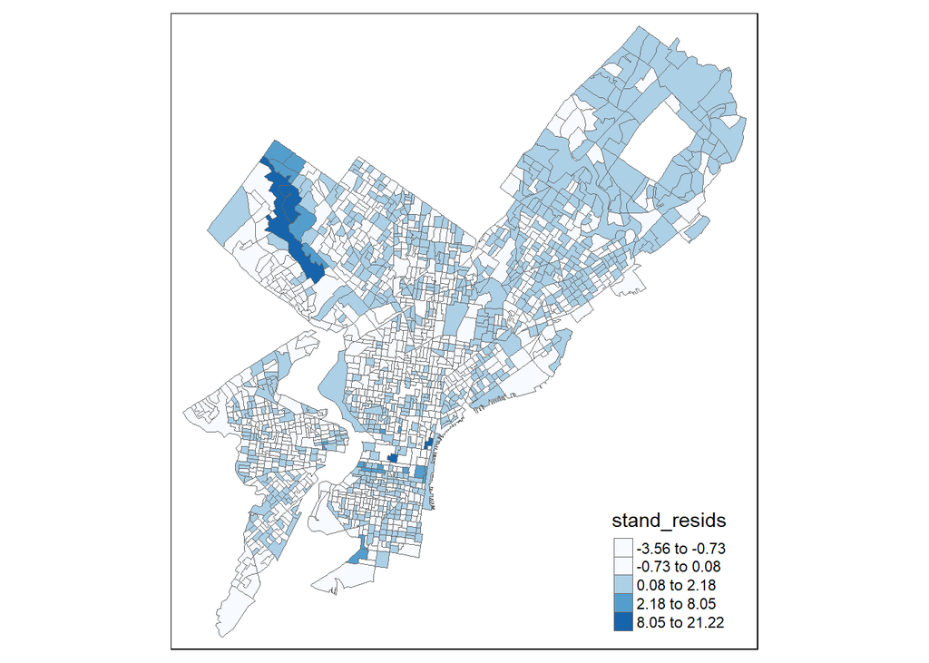

```r
tm_shape(reg_data) +
  tm_polygons(col = "stand_resids", border.col = NA, lwd = 0, palette = "Blues", style = "jenks") +
  tm_layout(legend.position = c("right", "bottom"))
```

### 0.3.4 Additional Models

#### 0.3.4.1 Stepwise Regression

Present the results of the stepwise regression and state whether all 4 predictors in the original model are kept in the final model.

```r
stepAIC(lm)
```

```
## Start:  AIC=36468.43
## MEDHVAL ~ PCTVACANT + PCTSINGLES + PCTBACHMOR + ln_n_bel_pov_100
##
##                    Df  Sum of Sq        RSS   AIC
## <none>                           2.7616e+12 36468
## - PCTVACANT         1 4.7073e+10 2.8087e+12 36495
## - ln_n_bel_pov_100  1 6.0614e+10 2.8222e+12 36504
## - PCTSINGLES        1 1.5480e+11 2.9164e+12 36560
## - PCTBACHMOR        1 1.9165e+12 4.6781e+12 37373
```

```
##
## Call:
## lm(formula = MEDHVAL ~ PCTVACANT + PCTSINGLES + PCTBACHMOR +
##     ln_n_bel_pov_100, data = reg_data)
##
## Coefficients:
##      (Intercept)         PCTVACANT        PCTSINGLES        PCTBACHMOR
##          60167.5            -578.9             754.9            2051.9
## ln_n_bel_pov_100
##          -5681.2
```

```r
anova(lm)
```

```
## Analysis of Variance Table
##
## Response: MEDHVAL
##                    Df     Sum Sq    Mean Sq  F value    Pr(>F)
## PCTVACANT           1 6.6026e+11 6.6026e+11  410.032 < 2.2e-16 ***
## PCTSINGLES          1 5.0734e+11 5.0734e+11  315.064 < 2.2e-16 ***
## PCTBACHMOR          1 2.1998e+12 2.1998e+12 1366.112 < 2.2e-16 ***
## ln_n_bel_pov_100    1 6.0614e+10 6.0614e+10   37.642 1.053e-09 ***
## Residuals        1715 2.7616e+12 1.6103e+09
## ---
## Signif. codes:  0 '***' 0.001 '**' 0.01 '*' 0.05 '.' 0.1 ' ' 1
```

#### 0.3.4.2 K-Fold Cross-Validation

Present the cross-validation results – that is, compare the RMSE of the original model that includes all 4 predictors with the RMSE of the model that only includes PCTVACANT and MEDHHINC as predictors.

```r
#----
#IGNORING THIS BC I RAN INTO ISSUES W THIS PACKAGE

#RMSE for full model
#cvlm_data = reg_data |>
#              st_drop_geometry() |>
#              dplyr::select(MEDHVAL,
#                            PCTVACANT,
#                            PCTSINGLES,
#                            PCTBACHMOR,
#                            ln_n_bel_pov_100)

#CVlm(data = cvlm_data, form.lm = lm, m = 5)

#class(lm)

#CVlm(reg_data, form.lm = lm, m =5)

#RMSE for model with only PCTVACANT and MEDHHINC
#----


#running into some weird errors with the DAAG cv.lm function
#trying a different one

#rmse for full model
lm_ii = trainControl(method = "cv", number = 5)

cvlm_model = train(MEDHVAL ~ PCTVACANT + PCTSINGLES + PCTBACHMOR + ln_n_bel_pov_100, data = reg_data, method = "lm", trControl = lm_ii)

print(cvlm_model)
```

```
## Linear Regression
##
## 4844 samples
##    5 predictor
##
## No pre-processing
## Resampling: Cross-Validated (5 fold)
## Summary of sample sizes: 3875, 3876, 3874, 3875, 3876
## Resampling results:
##
##   RMSE     Rsquared   MAE
##   29641.9  0.5582916  15847.7
##
## Tuning parameter 'intercept' was held constant at a value of TRUE
```

```r
#rmse for reduced model (just PCTVACANT and MEDHHINC)
lm_ii_reduced = trainControl(method = "cv", number = 5)

cvlm_model_reduced = train(MEDHVAL ~ PCTVACANT + MEDHHINC, data = reg_data, method = "lm", trControl = lm_ii_reduced)

print(cvlm_model_reduced)
```

```
## Linear Regression
##
## 4844 samples
##    3 predictor
##
## No pre-processing
## Resampling: Cross-Validated (5 fold)
## Summary of sample sizes: 3877, 3874, 3875, 3874, 3876
## Resampling results:
##
##   RMSE      Rsquared   MAE
##   35766.02  0.3489451  19333.13
##
## Tuning parameter 'intercept' was held constant at a value of TRUE
```

## 0.4 Discussion and Limitations

### 0.4.1 Recap

Recap what you did in the paper and your findings. Discuss what conclusions you can draw, which variables were significant and whether that was surprising or not.

### 0.4.2 Quality of Model

Talk about the quality of the model – that is, state if this is a good model overall (e.g., R2, F-ratio test), and what other predictors that we didn’t include in our model might be associated with our dependent variable.

If you ran the stepwise regression, did the final model include all 4 predictors or were some dropped? What does that tell you about the quality of the model?

If you used cross-validation, was the RMSE better for the 4 predictor model or the 2 predictor model?

### 0.4.3 Limitations of Model

If you haven’t done that in the Results section, talk explicitly about the limitations of the model – that is, mention which assumptions were violated, and if applicable, how that may affect the model/parameter estimation/estimated significance.

In addition, talk about the limitations of using the NBELPOV100 variable as a predictor – that is, what are some limitations of using the raw number of households living in poverty rather than a percentage?